# Final Project

Davide Aureli

25 Luglio 2018

# Library

```r
library(R2jags)
library(lattice)
library(dplyr)
library(knitr)
library(dplyr)
library(igraph)
library(plotrix)
```

```r
set.seed(972006)
```

# Introduction

Within this project we will try to analyze the results of the last football season of *Serie A season 2017-2018*, through the use of statistical tools such as **hierarchical Bayesian models**.

The data were taken from the site http://www.football-data.co.uk/mmz4281/1718/E0.csv

The work consists of four phases, each of which will be reserved a chapter:

1)Data observation and analysis on their distribution.

2)Construction of the Bayesian hierarchical models, through which we will study the trends of the offensive and defensive intensity of all the teams that took part in the championship in the 17/18 season.

3)Construction of a frequentist model and comparison between the two approaches.

4)Evaluation of the predictive performance of the model during the same season, using a betting strategy by applying these forecasts to bookmakers’ odds.

# Data Analysis

```r
#Loading data
Serie_A <- read.csv("C:/Users/user/Desktop/Tardella/Dati_Serie_A.csv")
```

Our initial analysis will focus on the 380 league matches completed by the 20 teams, considering the final result of the individual challenges.

For this reason we select the variables: “HomeTeam” “AwayTeam” “FTHG” “FTAG”

*Legenda*

**HomeTeam** = Home Team

**AwayTeam** = Away Team

**FTHG** = Full Time Home Team Goals

**FTAG** = Full Time Away Team Goals

```r
#Selecting variables
new_data = Serie_A[,c(3:6)]

#At first glance of our dataset
kable(new_data[1:6,])
```

| HomeTeam | AwayTeam | FTHG | FTAG |
| --- | --- | --- | --- |
| Juventus | Cagliari | 3 | 0 |
| Verona | Napoli | 1 | 3 |
| Atalanta | Roma | 0 | 1 |
| Bologna | Torino | 1 | 1 |
| Crotone | Milan | 0 | 3 |
| Inter | Fiorentina | 3 | 0 |

```r
#Transformation of data from categorical string to categorical numerical
new_data$HomeTeam <- as.numeric(new_data$HomeTeam)
new_data$AwayTeam <- as.numeric(new_data$AwayTeam)

#Select the goal columns at home and away from home
home_g <- new_data$FTHG
away_g <- new_data$FTAG

#Selected the number of matches in a season (380) and the number of teams (20)
match <- length(new_data$HomeTeam)
team <- length(unique(new_data$HomeTeam))
```

To model the distribution of the number of goals in sport events involving two competing teams, it’s possible to use the **Poisson distribution**, defined as follows:

$$X \sim Pois(\theta)=\frac{\theta^{k}}{k!}e^{-\theta}$$

Let’s analyze the behaviour of the observed data, in order to understand if in our case the Poisson distribution is a good choice.

We can start by observing the average goals scored during the championship for each match.

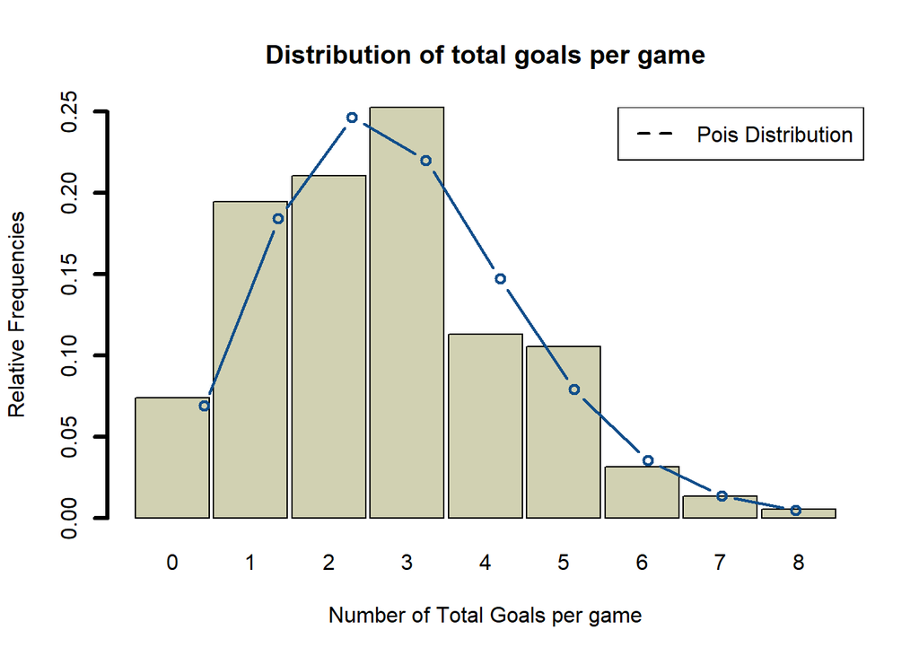

```r
#  Bar Plot

#tot goal per match
tot_gol <- home_g+away_g
counts <- table(tot_gol)

#Average of goals in a single match
avg_goal = mean(tot_gol)

barplot(table(tot_gol)/match, col =rgb(0.4,0.4,0,0.3), space=0.06,main="Distribution of total goals per game",xlab="Number of Total Goals per game",ylab="Relative Frequencies",lwd=3)
points( dpois(0:8, lambda=avg_goal ), type="b",lwd=2,col="dodgerblue4")
legend("topright",legend = c("Pois Distribution"),
       lty=2,lwd=2)
```

```r
#Avg Goals
avg_goal
```

```
## [1] 2.676316
```

Moreover we can focus on the differences between the **Home goal** VS the **Away goal**:

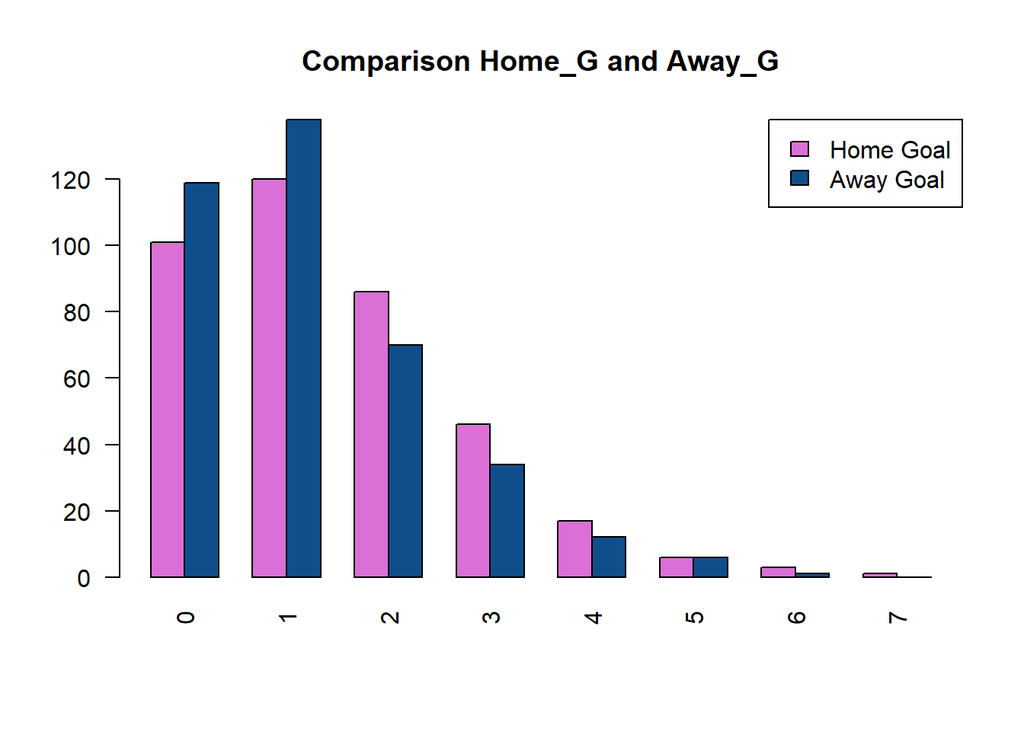

```r
aa <-table(home_g)
bb <- table(away_g)
aa <- as.matrix(aa)
bb <- as.matrix(bb)
bb= rbind(bb,0)
cc <- cbind(aa,bb)

col_1 <- rgb(0,0,1)
col_2 <- rgb(1,0,0)

barplot(t(cc), las=2, beside=T, col=c("orchid","dodgerblue4"), main="Comparison Home_G and Away_G",legend.text = c("Home Goal","Away Goal"), args.legend = list(x = "topright",col=c("orchid","dodgerblue4")))
```

As we observed previously for total goals in a single game, we can now see how both home and away goals are distributed, using the Poisson distribution with a parameter equal to the average at home and away.

Analyzing them, **overlapping the Poisson distribution**:

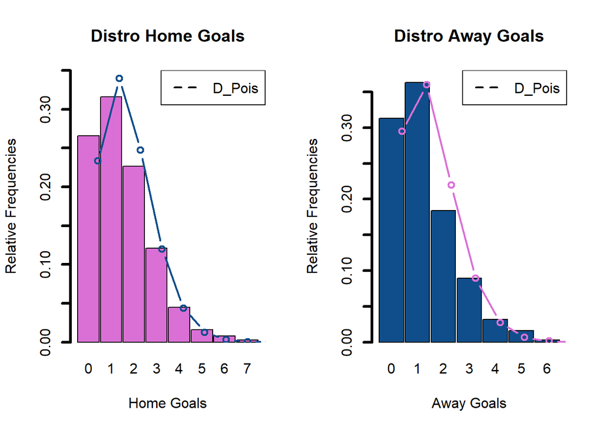

```r
#tot goal per match
tot_gol_home <- home_g
tot_gol_away <- away_g



#Average of goals in a single match both for away and home team
avg_goal_h = mean(tot_gol_home)
avg_goal_a = mean(tot_gol_away)

par(mfrow=c(1,2))

barplot(table(tot_gol_home)/match, col ="orchid", space=0.06,main="Distro Home Goals",xlab="Home Goals",ylab="Relative Frequencies",lwd=3,ylim=c(0,0.35))
points( dpois(0:8, lambda=avg_goal_h ), type="b",lwd=2,col="dodgerblue4")
legend("topright",legend = c("D_Pois"),
       lty=2,lwd=2)

barplot(table(tot_gol_away)/match, col ="dodgerblue4", space=0.06,main="Distro Away Goals",xlab="Away Goals",ylab="Relative Frequencies",lwd=3,ylim=c(0,0.38))
points( dpois(0:8, lambda=avg_goal_a ), type="b",lwd=2,col="orchid")
legend("topright",legend = c("D_Pois"),
       lty=2,lwd=2)
```

```r
par(mfrow=c(1,1))
```

In both the cases the **Poisson distribution seems to fit well** with the observed data. For the goal scored by the home team we use as parameter for the Poisson distribution the mean of the goal scored by all the home teams in the 2017-2018 season. The same reasoning we use for the away team.

In fact for the Poisson distribution is valide the following statement:
$$E(X)=\theta$$
where $X\sim Pois(\theta)$

```r
c("Home team" = mean(new_data$FTHG), "Away team" = mean(new_data$FTAG))
```

```
## Home team Away team
##  1.455263  1.221053
```

Observing the goals scored by the home teams and those who played away, we understand how on average the former express a **more offensive game**. It is useful to focus on the percentages of the results of the teams that played at home and away.

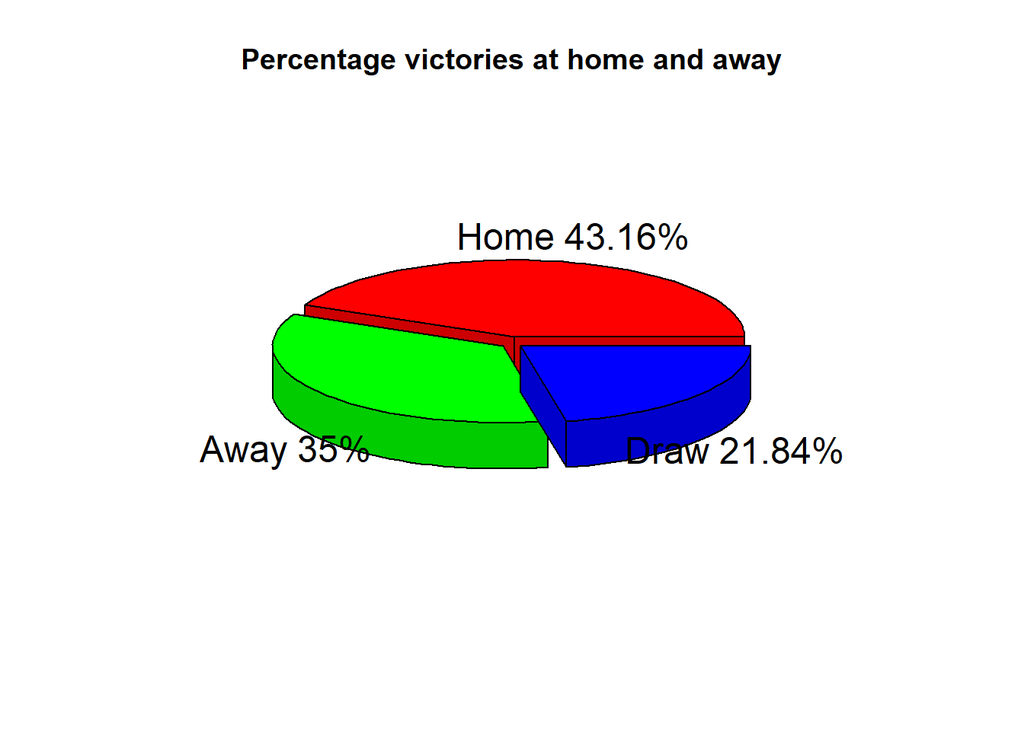

```r
#Creation of a vector taking the track of the results for each match, for us 1 = Home Victory, 2 = Away Victory , 3 = Draw
partite_fin <-NULL

for (partita in 1:nrow(new_data)){
  #print(partita)
  if (new_data[partita,3] > new_data[partita,4]){
    partite_fin[partita] <- 1
  }
  if (new_data[partita,3] < new_data[partita,4]){
    partite_fin[partita] <- 2
  }
  {
  if (new_data[partita,3] == new_data[partita,4]){
    partite_fin[partita] <- 3
  }
  }
}

# 3D Exploded Pie Chart

slices <- round((table(partite_fin)*100/match),2)

#Labels Creation
a <- paste0("Home ",slices[1],"%")
b <- paste0("Away ",slices[2],"%")
c <- paste0("Draw ",slices[3],"%")

lbls <- c(a, b, c)
#Plot
pie3D(slices,labels=lbls,explode=0.05,main="Percentage victories at home and away")
```

### Home Effect

Observing the average goals scored at home and away and observing the pie chart in which we highlight the percentages of victory at home and away, we can focus our attention on the **home factor**.

The field factor, defined in the project as “home”, which represents the existence of an **advantage for those who play at home**, in football (*Pollard, 2008*).

There remains to be clarified what are the precise causes and the way in which they **influence (positively)** the performance of a team playing in their home ground.

Several researches since the 80s have underlined a series of effects and the interaction between them. We list some of the most relevant:

- *Public*: the most famous and discussed effect, it is not yet clear whether it gives advantage to those who are at home or disadvantage to the host, nor if the number of spectators is in fact important.
- *Arbitrage*: it is easily deducible from the statistics of cards and penalties as the home team is generally favored, but this could only be an effect of the more effective tactics of those playing at home, although the public can also have a psychological influence.
- *Travel*: the distance traveled from the visiting team can slightly lighten the physical state. This is why in the so-called derby it is said that the field factor is lower.
- *Psychological factors*: the home team plays on familiar ground and in a familiar environment.
- *Tactical approach*: it is known to many as the teams at home tend to attack more for making a good impression in front of their public.

# Model Structure

The search for the most suitable models to describe **sports data** is a very popular topic and much literature has been produced in this sense since the ’70s.From a statistical point of view, many have found this topic very stimulating because it has some interesting aspects also of an economic nature (*Baio & Blangiardo, 2010*).

A first question was the search for the right distribution associated to the number of goals scored in a single game by the two teams, because these quantities we deal with, as well as being all we need to know the result of a meeting, they are generally small and not negative numbers, also called *low counts*.

The first models (*Pollard et al., 1977*) proposed the Binomial or the Negative Binomial, but afterwards the **distribution of Poisson** was globally accepted; this is the reason for the first plot in the Introduction. To simplify things, on the basis of empirical studies that showed the almost nullity of the correlation between goals scored by the two teams in the field, *Maher* (1982) hypothesized that the **two Poissonian variables were independent** and more in particular that both were the product of the strength offensive of a team and the defensive ability of its adversary.

In the following years, relatively low but non-zero correlation levels were shown between the two quantities (*Karlis & Ntzoufras, 2000*), so changes were proposed to Maher’s model as corrective factors to improve its predictive performance.

In the early 2000s, various authors (*Karlis & Ntzoufras, 2003*) proposed the use of a more complete attribution to the **Poisson bivariata**, which allows the introduction of the covariance between goals scored by the two opposing teams, all in a Bayesian context.

Following *Baio and Blangiardo (2010)* have theorized **the Bayesian hierarchical model** showing that with such a structure there is no need for additional parameters for the covariance between goals since assuming **two Poissonian variables conditionally independent** for the goals scored, the correlation is considered at a higher level of the hierarchical structure.

The conditionally independence of the two Poisson variables could be formalized in the following formula:

$$Y_{gj} \mid \theta_{gj} \sim Poisson(\theta_{gj})$$

and ${j =1,2}$ represent the two teams that we are observing in a match.

Where $Y_{gj}$ is the number of goals we can observe in the game $g-th$ between the team $j = 1$ and $j = 2$.

Let’s focus now on the parameter $\theta_{gj}$: it’s the **realization intensity**. It’s possible to understand the importance of this parameter considering that, for a Poisson distribution, we have that:

$$\mathbb{E}\big[Pois(\lambda)\big] = \lambda$$

*But.. from what the realization intensity of a team is influenced by ?*

It’s reasonable to think that it’s influenced by:

- **attack potential** of the team ($alpha_{j}$)
- **defense potential** of the opponent team ($beta_{i}$)
- **home factor** ($\delta$)

Now, we are able to construct our model taking inspiration from this last paper, trying to represent the hierarchical Bayesian model structure through the DAG.

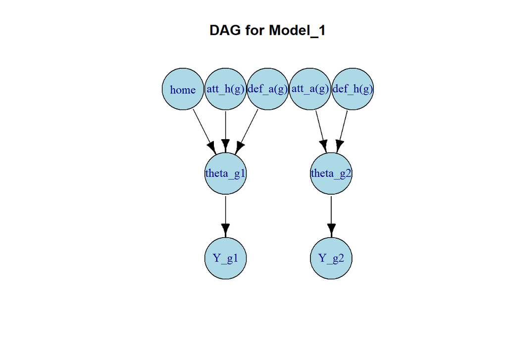

```r
#Representation of the DAG

graph <- make_empty_graph(directed=T)
graph <- graph + vertex(color= 'lightblue',name=expression(Y_g1))+vertex(color= 'lightblue',name=expression(Y_g2))+vertex(color= 'lightblue',name=expression(theta_g1))+vertex(color= 'lightblue',name=expression(theta_g2))+vertex(color= 'lightblue',name="home")+vertex(color= 'lightblue',name="att_h(g)")+vertex(color= 'lightblue',name="def_a(g)")+vertex(color= 'lightblue',name="att_a(g)")+vertex(color= 'lightblue',name="def_h(g)")


graph <- graph + edge(3,1)+ edge(4,2)+ edge(5,3)+ edge(6,3)+ edge(7,3)+ edge(8,4)+ edge(9,4)
l <- layout_with_sugiyama(graph, layers = NULL, hgap = 1, vgap = 1,
  maxiter = 100, weights = NULL, attributes = c("default", "all", "none"))

plot(graph, layout=l$layout,edge.color='black', main="DAG for Model_1", vertex.size=50, edge.arrow.size=0.9)
```

In this hierarchical model the goals of the two opponent teams are explained using two levels. We’ve to show how $\theta_{g(1)}$ and $\theta_{g(2)}$ are composed.

The way used to explain **the realization intensity**, according with variables shown before, is the following one:

$$\theta_{x,j,i,t} = \exp(\delta+\alpha_{i,t}+\beta_{j,t})$$

$$\theta_{y,j,i,t} = \exp(\alpha_{j,t}+\beta_{i,t})$$

So that our parameters to be estimated are $\alpha$, $\beta$ and *home* for each team. **The log function is used in order to remap the value of the linear combination of the parameters in the same space of $\theta$’s domain**.

Regarding the parameters of interest we used the following **priors**:

- $a \sim N(0, \dfrac{1}{0.01})$
- $b \sim N(0, \dfrac{1}{0.01})$
- $home \sim N(0, \dfrac{1}{0.001})$

Since no information is available, normal prior distibutions for the parameters with mean zero and large variance are used to express our idea that is **skeptical but flexible**.

In order to run the model in a Bayesian framework, we’ll use *Jags*. It’s important to underline that in the Jags code when some Normal prior distributions are initialized, the second parameters is the **precision**, instead of the variance. Remember that the precision $\tau$ is:

$$\tau = \dfrac{1}{\sigma^2}$$

Now it’s important to initialize the parameters for the **Model_1**

# Model 1

We initialize the input parameters, which then will be irrelevant for the behavior implemented by the MCMC(Monte Carlo Markov Chain).

Also for the attack we will have positive values that indicate a team with a good vein of realization while vice versa no, for the defense the meaning is contrary we will have negative values that indicate a good defense and positive a colander … Everything will be clearer by observing model.

```r
# Initialization

soccer.init = list(list("home" = 0.7, "a" = c(NA,rep(0.2, team-1)), "d" = c(NA,rep(0.2, team-1))), list("home" = 0.7, "a" = c(NA,rep(0.2, team-1)), "d" = c(NA,rep(0.2, team-1))))

# PARAMETERS OF INTEREST
soccer.param = c("a", "d", "home")
```

Here we create the data in the structure that requires *JAGS*.

```r
soccer.data = list(x = new_data$FTHG, y = new_data$FTAG, number_match = match, number_teams = team, ht = new_data$HomeTeam, at = new_data$AwayTeam)
```

The Jags code is the following one:

```r
'''
model{
  for (i in 1:number_match){
    # stochastic component
    x[i]~dpois(lambda1[i])
    y[i]~dpois(lambda2[i])
    # link and linear predictor
    log(lambda1[i])<-  home + a[ ht[i] ] + d[ at[i] ]
    log(lambda2[i])<-  a[ at[i] ] + d[ ht[i] ]
  }
  # STZ constraints
  a[1]<-  -sum( a[2:20] )
  d[1]<-  -sum( d[2:20] )
  #

  # prior distributions
  home~dnorm(0,0.001)

  for (i in 2:number_teams){
    a[i]~dnorm(0,0.01)
    d[i]~dnorm(0,0.01)
  }

}
'''
```

Here we load the model and we can run it. With the variable *model_1* we store all the output values of our chains.

```r
model_1 = jags(data = soccer.data, inits = soccer.init,
                parameters.to.save = soccer.param,
                model.file = "C:/Users/user/Desktop/Tardella/model_1.txt",
                n.chains = 2,
                n.iter = 50000, n.burnin = 25000)
```

```
## module glm loaded
```

Before seeing what we got let’s discuss on the parameters used in the model. In order to use the *Jags* environment we use the *jags* function.

In details the following parameters are setted:

- **number of iterations**: 50000. This parameter is the total lenght of the Markov Chain
- **number of chains**: 2
- **burn-in**: 25000. It’s the number of iterations to discard at the beginning
- **n.thin**: 25. It’s the thinning rate and it must be a positive integer

Now we can print the results of our model.

```r
mm1 <- as.mcmc(model_1)
summary(mm1)
```

```
##
## Iterations = 25001:49976
## Thinning interval = 25
## Number of chains = 2
## Sample size per chain = 1000
##
## 1. Empirical mean and standard deviation for each variable,
##    plus standard error of the mean:
##
##                Mean       SD Naive SE Time-series SE
## a[1]        0.16688  0.17414 0.003894       0.004207
## a[10]       0.57666  0.11111 0.002484       0.002661
## a[11]       0.63638  0.10472 0.002342       0.002309
## a[12]       0.15851  0.13730 0.003070       0.003269
## a[13]       0.46560  0.11160 0.002495       0.002629
## a[14]       0.22978  0.13379 0.002992       0.003564
## a[15]       0.17366  0.13088 0.002927       0.003095
## a[16]      -0.51905  0.19155 0.004283       0.005272
## a[17]      -0.20987  0.15827 0.003539       0.003919
## a[18]       0.11434  0.13554 0.003031       0.003218
## a[19]       0.01328  0.14733 0.003294       0.003758
## a[2]       -0.35323  0.17043 0.003811       0.004461
## a[20]      -0.46329  0.18439 0.004123       0.004903
## a[3]       -0.18457  0.15840 0.003542       0.003772
## a[4]       -0.38139  0.17775 0.003975       0.004571
## a[5]       -0.29440  0.17170 0.003839       0.004405
## a[6]       -0.16924  0.15550 0.003477       0.004047
## a[7]        0.11628  0.13704 0.003064       0.003375
## a[8]       -0.38932  0.16850 0.003768       0.004347
## a[9]        0.31298  0.12401 0.002773       0.002921
## d[1]       -0.22115  0.19989 0.004470       0.005229
## d[10]      -0.69403  0.20952 0.004685       0.005722
## d[11]       0.06261  0.14389 0.003217       0.003617
## d[12]      -0.13685  0.15382 0.003440       0.003681
## d[13]      -0.50314  0.18510 0.004139       0.004807
## d[14]      -0.55814  0.19423 0.004343       0.004961
## d[15]       0.23504  0.13256 0.002964       0.003057
## d[16]       0.19009  0.13177 0.002946       0.003030
## d[17]       0.19673  0.12997 0.002906       0.003235
## d[18]      -0.04268  0.14778 0.003305       0.003893
```

[output cut: 43 more lines]

```
## d[16]      -0.07766    0.10402  1.894e-01    0.28328    0.44087
## d[17]      -0.07525    0.11474  1.997e-01    0.28839    0.43732
## d[18]      -0.34663   -0.14208 -3.906e-02    0.05819    0.23229
## d[19]       0.01034    0.18989  2.777e-01    0.35662    0.50961
## d[2]        0.33788    0.48353  5.583e-01    0.62853    0.76404
## d[20]       0.24899    0.39943  4.784e-01    0.55429    0.69804
## d[3]       -0.22445   -0.03019  6.705e-02    0.16240    0.32602
## d[4]       -0.02540    0.14102  2.280e-01    0.31614    0.46527
## d[5]       -0.04722    0.11818  2.059e-01    0.28935    0.44435
## d[6]        0.05507    0.23120  3.163e-01    0.39806    0.54724
## d[7]       -0.33201   -0.13351 -3.288e-02    0.06641    0.25684
## d[8]       -0.43148   -0.22969 -1.345e-01   -0.03260    0.15047
## d[9]       -0.84976   -0.58009 -4.656e-01   -0.34710   -0.13383
## deviance 2118.64309 2128.24483  2.134e+03 2140.24840 2154.99526
## home        0.15203    0.20920  2.389e-01    0.26964    0.32041
```

#### Interpretation of the Summary

The **summary** method for the **mcmc** class provides numeric summaries of the *MCMC samples values* for each variable.

The **Mean** column provides the approximation of the posterior mean of the parameter of interest.

The **Standard Deviation** (SD) is the standard deviation of sampled values from the posterior. It provides information about certainty to which the value of the variable is known.

The **Naive Standard Error (SE)** provides information about the standard error in estimating the posterior mean. Increasing the number of monitored iterations in the MCMC run should decrease this standard error. The “naive” standard error is the standard error of the mean, which captures simulation error of the mean rather than posterior uncertainty: $naiveSE=\frac{\sigma}{\sqrt{n}}$.

We can derive this from the variance of the sample mean, that is: $Var(\bar{X})=Var(\frac{1}{n}\sum_{i=1}^{n}X_i)=\frac{1}{n^2}Var(\sum_{i=1}^{n}X_i)=\frac{n\sigma^2}{n^2}=\frac{\sigma^2}{n}$ Certainly it’s valid when we have an i.i.d sample but in our sample from the mcmc we are supposing the independence of the sample but **we know that autocorrelation is there**, which it will be analyzed later.

The **Time-Series Standard Error (SE)**is arguably the more informative value. The time-series standard error adjusts the “naive” standard error for autocorrelation. If there is auto-correlation then each iteration does not provide an independent unit of information. In this case, the time-series SE adjusts for the non-independence of each iteration.

The **Quantiles tables** provides various quantile estimates. It defaults to useful values, but different quantiles can be specified. In particular, the 50th percentile corresponds to the median. And the 2.5 and 97.5 percentiles can be combined to form a $95\%$.

Let’s see the estimated attack and defense coefficients for the Serie A teams:

```r
off_att <- model_1$BUGSoutput$mean$a
super_def <- model_1$BUGSoutput$mean$d
home_sweet <- model_1$BUGSoutput$mean$home

XY <- data.frame(cbind(levels(Serie_A$HomeTeam),off_att,super_def,home_sweet))
colnames(XY)<- c("Team","Attack","Defense","Home")

#Overview on the parameters
kable(XY)
```

| Team | Attack | Defense | Home |
| --- | --- | --- | --- |
| Atalanta | 0.166883629134977 | -0.221154394985792 | 0.239313862203767 |
| Benevento | -0.353230617429901 | 0.55651941481077 | 0.239313862203767 |
| Bologna | -0.184570162273396 | 0.0627882423952695 | 0.239313862203767 |
| Cagliari | -0.381389962155236 | 0.226153575424524 | 0.239313862203767 |
| Chievo | -0.294402765926488 | 0.201856615263031 | 0.239313862203767 |
| Crotone | -0.16923712176421 | 0.314811729598037 | 0.239313862203767 |
| Fiorentina | 0.116281589915155 | -0.0345889096946873 | 0.239313862203767 |
| Genoa | -0.389316261483468 | -0.135075315013946 | 0.239313862203767 |
| Inter | 0.312982262179318 | -0.469291434555766 | 0.239313862203767 |
| Juventus | 0.576663315478769 | -0.694032769215187 | 0.239313862203767 |
| Lazio | 0.63638376186277 | 0.0626086456223737 | 0.239313862203767 |
| Milan | 0.158514161735008 | -0.136853389355696 | 0.239313862203767 |
| Napoli | 0.465602456110842 | -0.503139834953061 | 0.239313862203767 |
| Roma | 0.229776664921604 | -0.558140298713115 | 0.239313862203767 |
| Sampdoria | 0.17365976851145 | 0.235037793364484 | 0.239313862203767 |
| Sassuolo | -0.519050764232072 | 0.190089423278952 | 0.239313862203767 |
| Spal | -0.209870465526382 | 0.196731707125816 | 0.239313862203767 |
| Torino | 0.114335454039046 | -0.0426816291298014 | 0.239313862203767 |
| Udinese | 0.0132799872460875 | 0.271563449185347 | 0.239313862203767 |
| Verona | -0.463294930343874 | 0.476797379548448 | 0.239313862203767 |

As we can see from **the a posteriori mean approximation**, defined as *Mean* within the summary, shows as the attack and defense parameters reflect reality. In fact the two best attacks are those of **Lazio** with 89 goals scored (att = 0.636) and then following **Juventus** with 86 goals (att= 0.576) and **Napoli** with 77 goals (0.465). While the worst is certainly **Sassuolo** team with a posteriori mean approximation related to the attack parameter of -0.519 with only 29 goals scored.

As for the defense the best team is Juventus with only 24 goals conceded(def=-0.694) while the worst is Benevento with 84 goals conceded (def=0.556).

As we said previously, the home value is the same for all teams, *home = 0.239*.

# Diagnostic

Once the approximation a posteriori of the parameters are obtained, **the convergence check is needed**. If the algorithm converges, it means it has reached its equilibrium (target) distribution and the generated sample comes from the correct target distribution. Hence, monitoring the convergence of the algorithm is essential for producing results from the posterior distribution. In order to study the convergence, plotting autocorrelation, trace plots and density plot are easy and fast tasks.

### Traceplot

Trace plots provide useful diagnostic estimation:

The trace plots show the value of a variable across the monitored iteractions of the MCMC chain. Trace plots can reveal auto-correlation which reduces the information provided by each iteration. Trace plots can reveal inadequate burn-in when early. We can see whether our chain gets stuck in certain areas of the parameter space, which indicates bad mixing. If you specify to monitor multiple chains, then the trace plot will display each chain in a different colour.

In particular we’ll print both the chain, the first one is the black one, while the second one is red.

[figure not shown]

[figure not shown]

[figure not shown]

[figure not shown]

[figure not shown]

[figure not shown]

[figure not shown]

```r
par(mfrow=c(3,2))
log.j = as.mcmc(model_1)
par_list <- colnames(log.j[[1]])
for (i in 1:dim(model_1$BUGSoutput$sims.array)[3])
{
  plot(model_1$BUGSoutput$sims.array[,1,i], type = "l", main=paste("Traceplot",par_list[i]))
  points(model_1$BUGSoutput$sims.array[,2,i], type = "l", col=rgb(1,0,0,0.7))
}
```

```r
par(mfrow=c(1,1))
```

### Autocorrelation

Autocorrelation calculates the autocorrelation function for the Markov chain mcmc.obj at the lags given by lags.**High autocorrelations within chains indicate slow mixing and, usually, slow convergence**. It may be useful to thin out a chain with high autocorrelations before calculating summary statistics: a thinned chain may contain most of the information, but take up less space in memory. Re-running the MCMC sampler with a different parameterization may help to reduce autocorrelation.

The lag k autocorrelation $\rho_k$ is the correlation between every draw and its k-th lag: $\rho_k=\frac{\sum_{i=1}^{n-k}(x_i-\bar{x})(x_{i+k}-\bar{x})}{\sum_{i=1}^{n}(x_i-\bar{x})^2}$.

We would expect the kth lag autocorrelation to be smaller as k increases.**If autocorrelation is still relatively high for higher values of k, this indicates high degree of correlation between our draws and slow mixing**.

So it seems as though the chains have converged after the iterations.

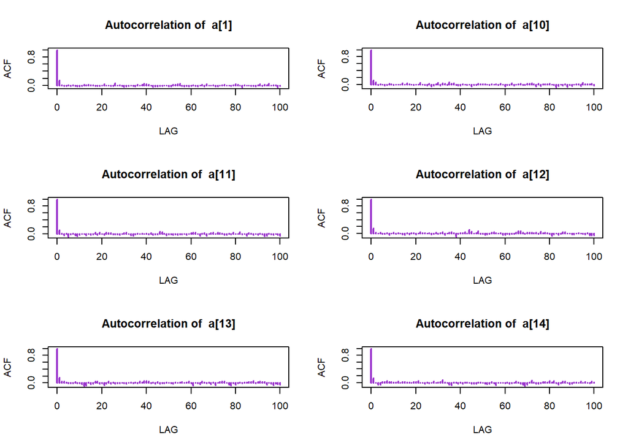

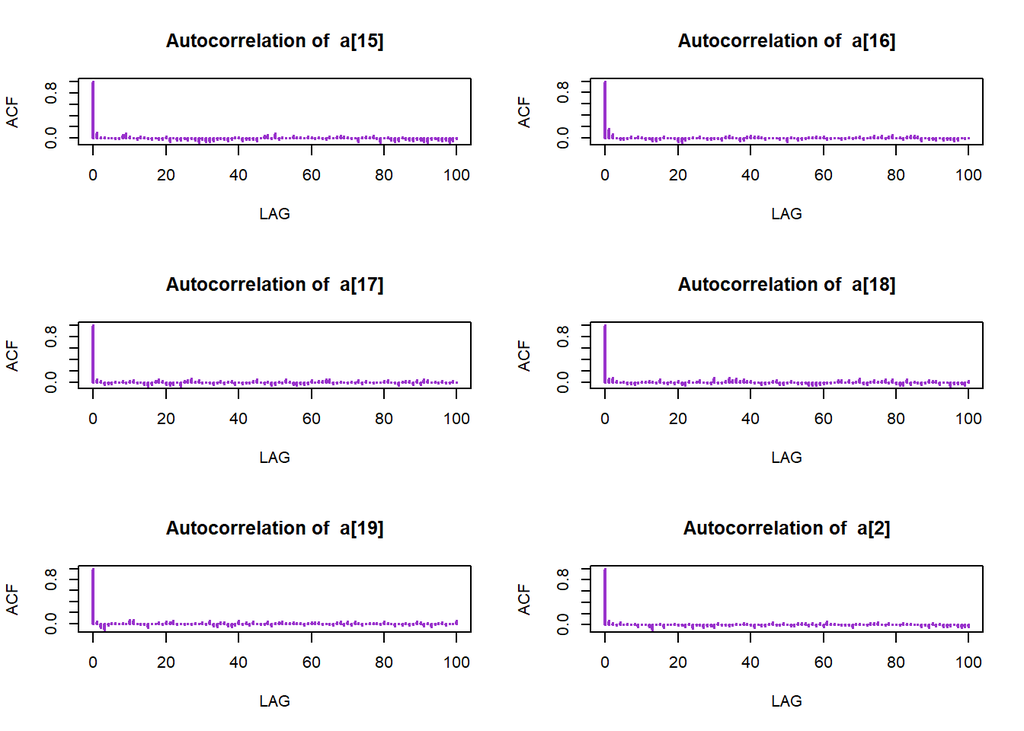

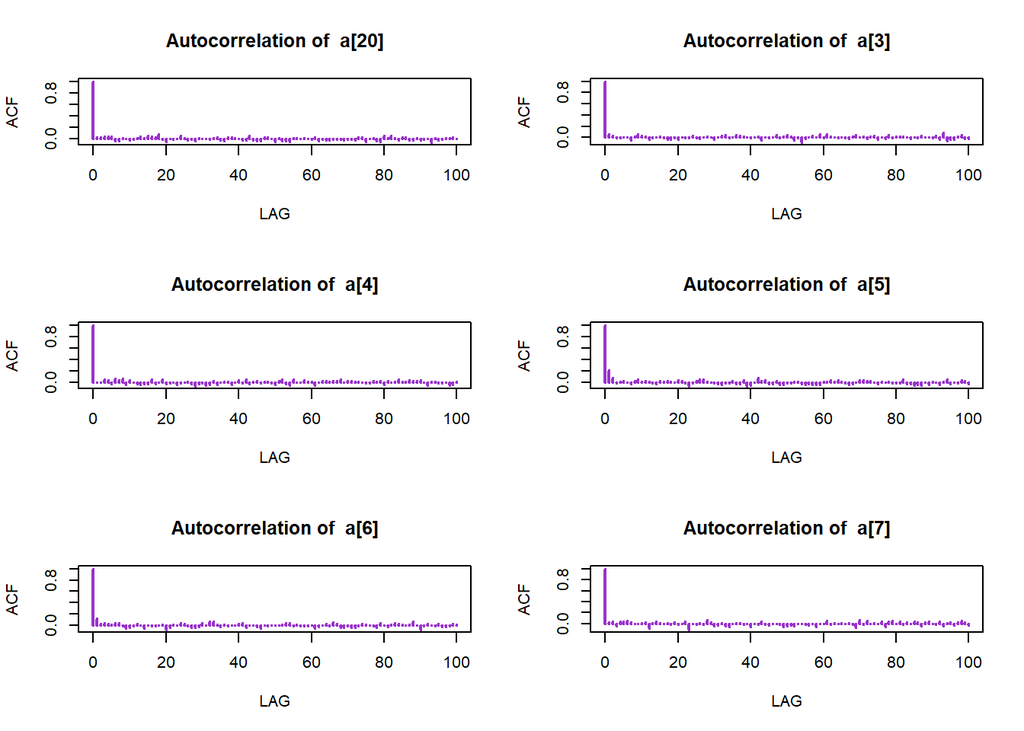

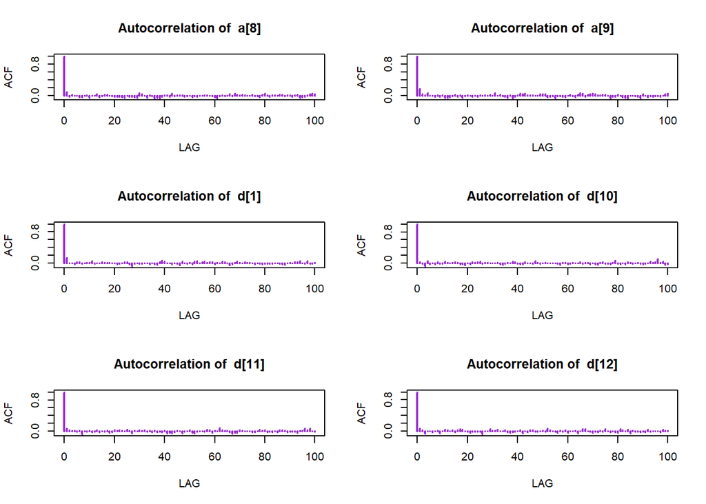

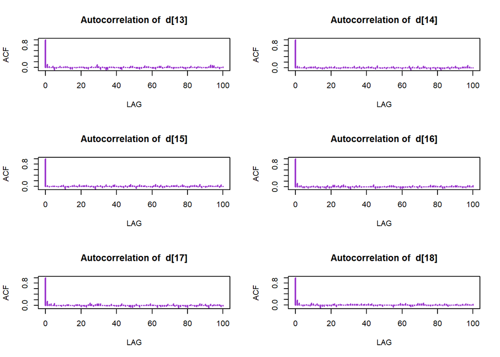

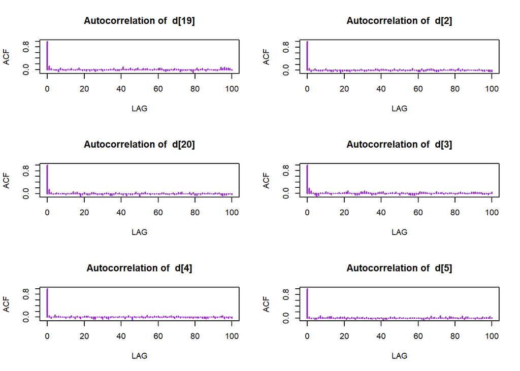

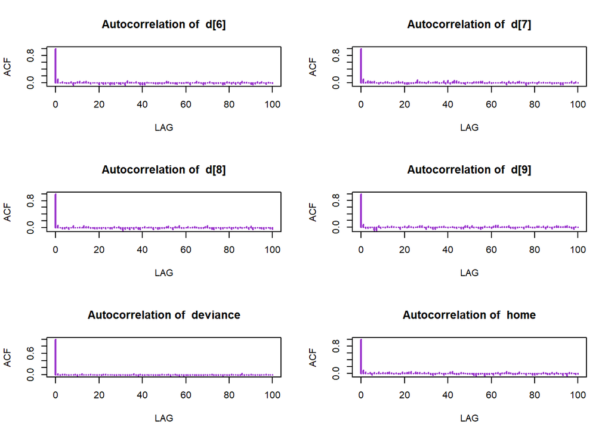

```r
par(mfrow=c(3,2))
for(i in 1:dim(model_1$BUGSoutput$sims.array)[3])
{
  acf_main <- acf(model_1$BUGSoutput$sims.array[,1,i], plot = F, lag.max=100)
  plot(acf_main$lag, acf_main$acf, type='h', col = 'darkorchid',  xlab="LAG", ylab="ACF", lwd=2, main=paste("Autocorrelation of ",par_list[i]))
}
```

```r
par(mfrow=c(1,1))
```

### Density plot

Density plots summarise the posterior density for each variable estimated based on the sampling of the variable in the MCMC chains.

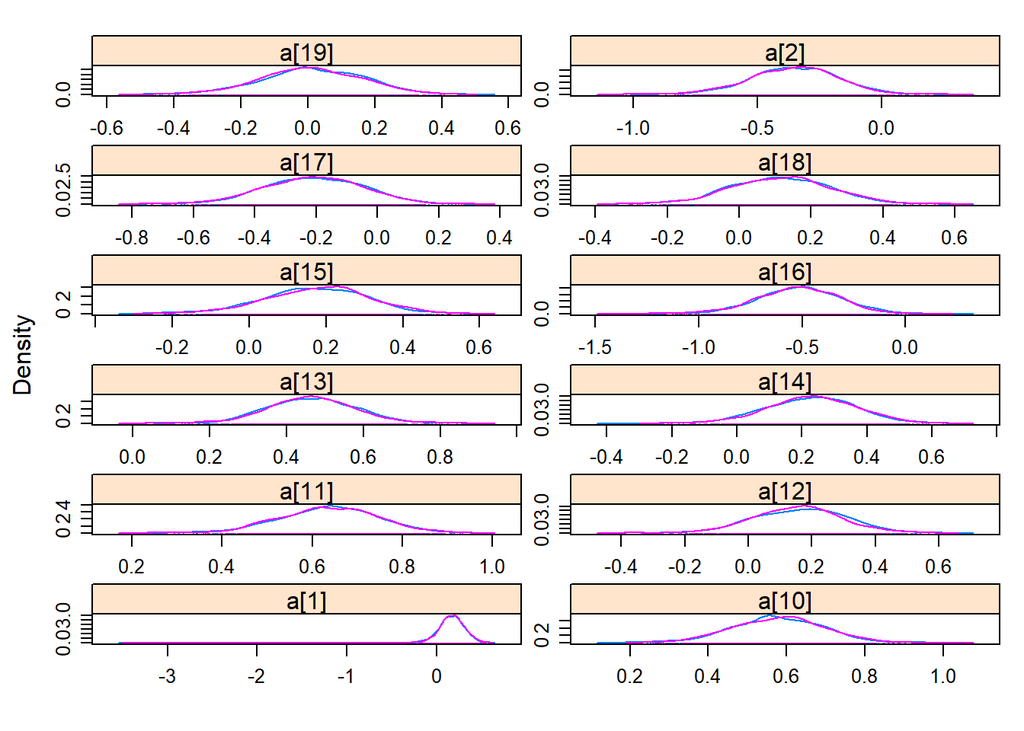

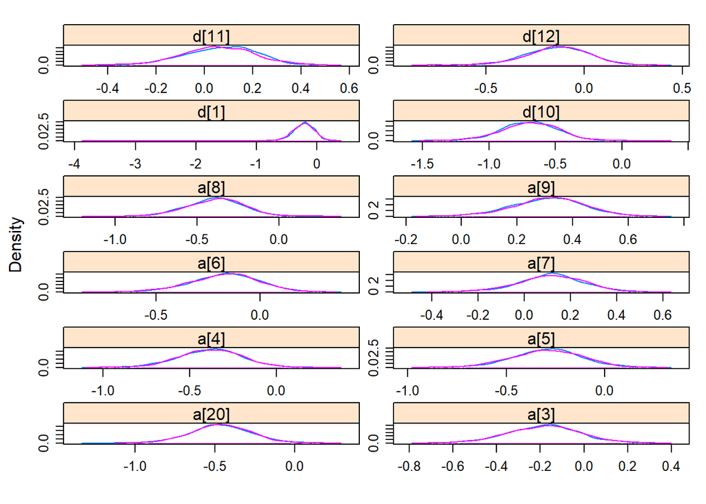

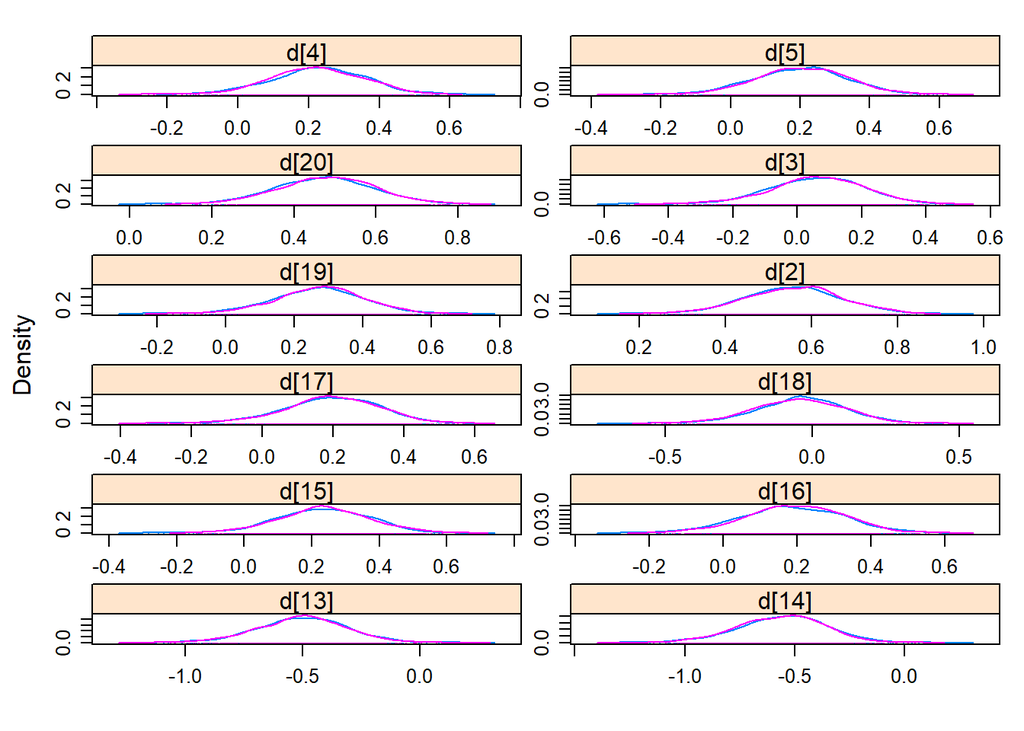

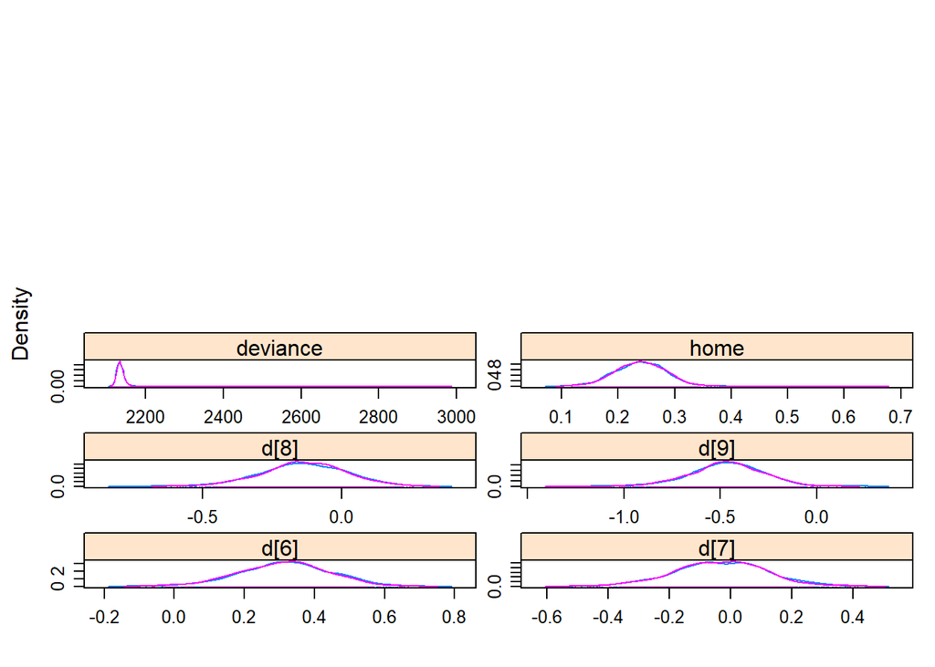

```r
par(mfrow=c(3,1))
densityplot(as.mcmc(model_1),layout=c(2,6),aspect="fill" )
```

```r
par(mfrow=c(1,1))
```

As it’s possible to see the posterior distributions are the same for both the analyzed chains.

Now we can check the goodness of the results obtained using hypothesis tests, we report two that were used in the project.

## Gelman and Rubin Convergence Diagnostic

Steps (for each parameter):

1. Run m >= 2 chains of length 2n from overdispersed starting values.
2. Discard the first n draws in each chain.
3. Calculate the within-chain and between-chain variance.
4. Calculate the estimated variance of the parameter as a weighted sum of the within-chain and between-chain variance.
5. Calculate the potential scale reduction factor.

Within Chain Variance:

$W=\frac{1}{m}\sum_{j=1}^{m}s_j^2$ where $s_j^2=\frac{1}{n-1}\sum_{i=1}^{n}(\theta_{ij}-\bar{\theta_j)^2}$. Where $s_j^2$ is just the formula for the variance of the j-th chain. W is then just the mean of the variances of each chain. W likely underestimates the true variance of the stationary distribution since our chains have probably not reached all the points of the stationary distribution.

*Between Chain Variance*:

$B=\frac{n}{m-1}\sum_{j=1}^{m}(\bar{\theta_j}-\bar{\bar \theta})^2$ where $\bar{\bar \theta}=\frac{1}{m}\sum_{j=1}^{m}\bar{\theta_j}$, this is the variance of the chain means multiplied by n because each chain is based on n draws.

*Estimated Variance*:

We can then estimate the variance of the stationary distribution as a weighted average of W and B. $\hat{Var}(\theta)=(1-\frac{1}{n})W+\frac{1}{n}B$. Because of overdispersion of the starting values, this overestimates the true variance.

*Potential Scale Reduction Factor*:

The potential scale reduction factor is: $\hat R=\sqrt{\frac{\hat{Var}(\theta)}{W}}$. When $\hat{R}$ is high (perhaps greater than 1.1 or 1.2), then we should run our chains out longer to improve convergence to the stationary distribution. If we have more than one parameter, then we need to calculate the potential scale reduction factor for each parameter.

We should run our chains out long enough so that all the potential scale reduction factors are small enough.

The results of the Gelman and Rubin diagnostic gives us the median potential scale reduction factor and its 97.5% quantile (the psrf is estimated with uncertainty because our chain lengths are finite).

```r
log.j = as.mcmc(model_1)
colnames(log.j[[1]])
```

```
##  [1] "a[1]"     "a[10]"    "a[11]"    "a[12]"    "a[13]"    "a[14]"
##  [7] "a[15]"    "a[16]"    "a[17]"    "a[18]"    "a[19]"    "a[2]"
## [13] "a[20]"    "a[3]"     "a[4]"     "a[5]"     "a[6]"     "a[7]"
## [19] "a[8]"     "a[9]"     "d[1]"     "d[10]"    "d[11]"    "d[12]"
## [25] "d[13]"    "d[14]"    "d[15]"    "d[16]"    "d[17]"    "d[18]"
## [31] "d[19]"    "d[2]"     "d[20]"    "d[3]"     "d[4]"     "d[5]"
## [37] "d[6]"     "d[7]"     "d[8]"     "d[9]"     "deviance" "home"
```

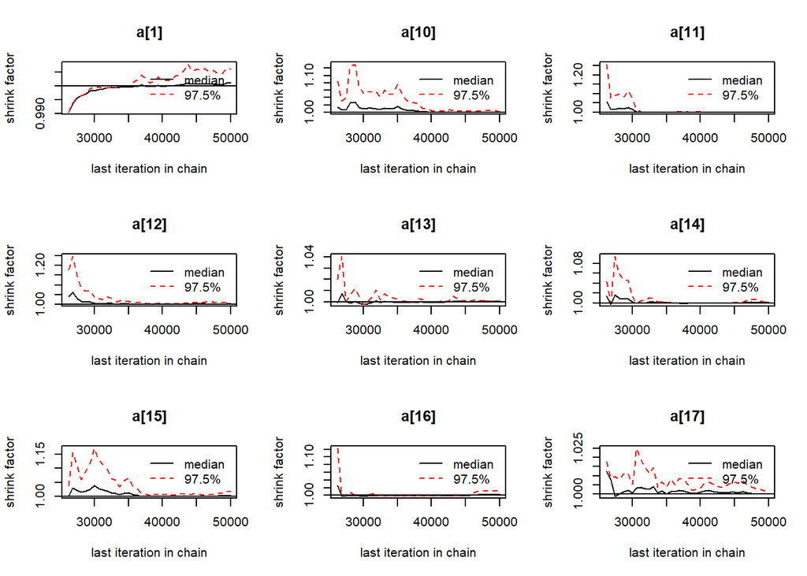

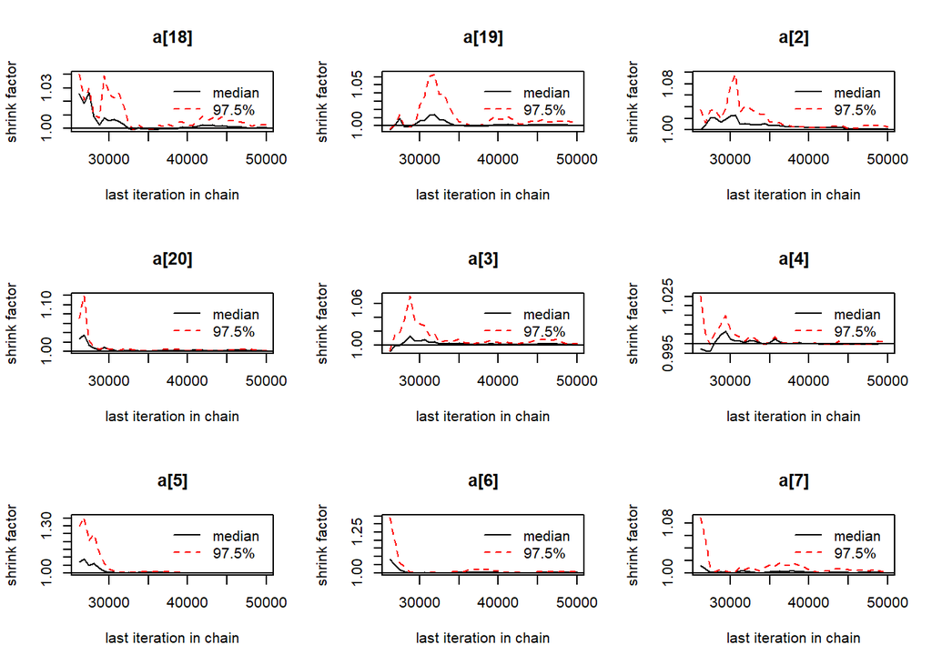

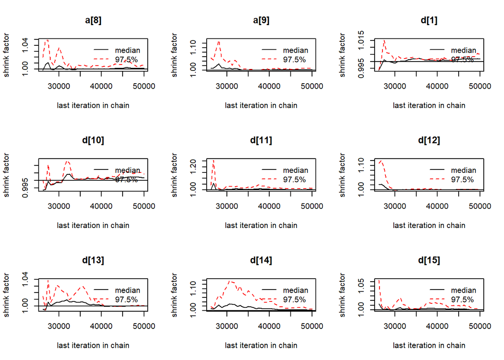

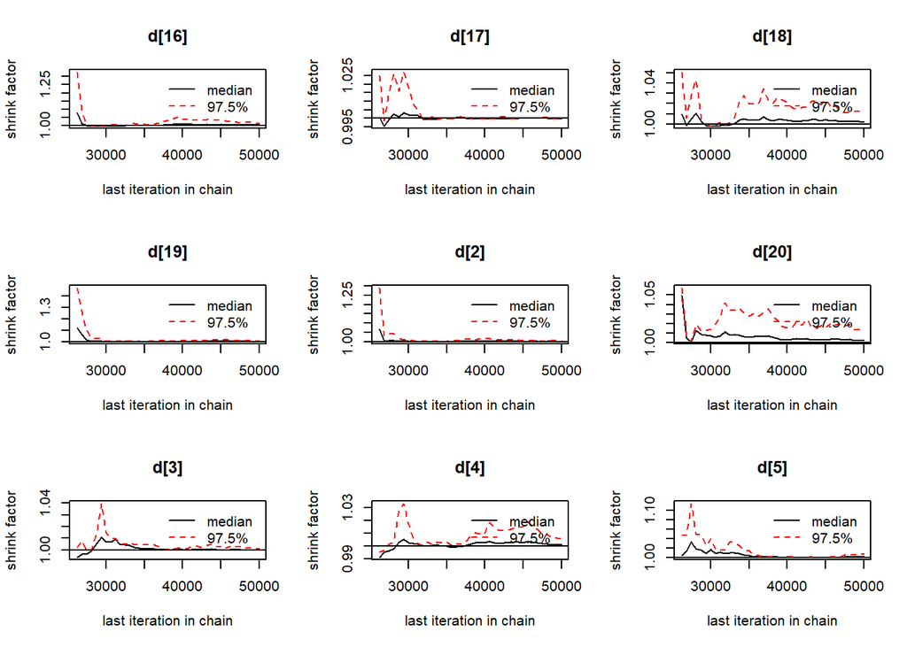

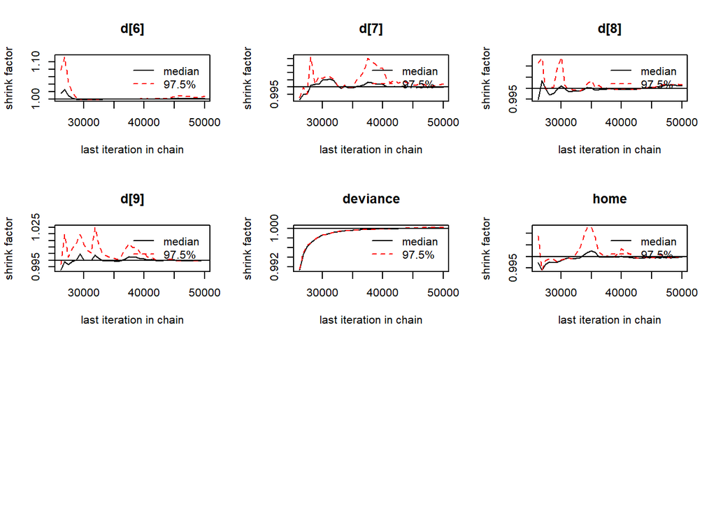

```r
gelman.plot(log.j)
```

As it’s possible to see for almost the totality of the parameters there is a convergence in the last iterations.

The Geweke diagnostic takes two non overlapping parts (usually the first 0.1 and last 0.5 proportions) of the Markov chain and compares the means of both parts, using a difference of means test to see if the two parts of the chain are from the same distribution (*null hypothesis*).

The test statistic is a standard Z-score with the standard errors adjusted for autocorrelation.

$Z= \frac{X_{1} - X_{2}}{se_{time series}}$ where X_{1} is the mean of the 10% of the sample(after eliminating the bur-in part) while X_{2} represents the mean of the last 50%.